```python
from IPython.core.display import HTML; HTML(filename='../lecture.css')
```

##### 7 Mar 2016

# Parallel Processing in Python

#### Wrapping Up the Biome Project

- SPMD computing
- Parallel `map` in Python
- Issues for parallel biome simulation

## von Neumann Architecture

The first published description of a **stored program computer** was the EDVAC

- John von Neumann was the first author
- we now refer to this general design as a "von Neumann machine"

[figure not shown]

### Fetch-Decode-Execute

The processor repeatedly executes the following operations

- **fetch** an instruction from memory
- **decode** the instruction to decide what to do
- **execute** the instruction

The kinds of operations that can be performed by a single machine instruction include

- fetch data from memory
- store data to memory
- arithmetic operations (add, subtract, ...)
- control instructions (compare two values, ...)

### Inside the CPU

The two major parts of a CPU are the **control unit** and the **arithmetic-logic unit**

- the ALU has the circuits that process data
- the control unit generates signals that control the operation of the rest of the CPU

[figure not shown]

### Multi-Core CPUs

Modern CPU chips often have more than one ALU

- instructions may come from more than one program
- each program has its own data

[figure not shown]

## SIMD

One way to build a multiprocessor system is to have one control unit simultaneously controlling several different ALUs

- SIMD = "single instruction multiple data"

[figure not shown]

### Commercial Systems

There were several computers based on this design

- Thinking Machines CM-1 (1985)
- MasPar MP-1 (1990)

The machines were highly successful but changing technology eventually made them obsolete

### GPUs

The same basic design is still in use today

The Graphics Processing Units (GPUs) found in modern CPU chips are SIMD processors

## SPMD

Although there are few general-purpose SIMD machines the style of programming developed for these machines is still wide-spread

SPMD = "single program multiple data"

Divide a data set into smaller pieces

- each CPU or core executes the same functions
- functions are applied to different parts of the data

## SPMD in Python: Parallel `map` Function

Python has several parallel processing libraries

- some are part of the standard library, just use `import`
- some need to be installed with `pip` or `conda`

To illustrate how to do SPMD style parallel computing the code in this section finds prime numbers in a list

The code includes a call to a parallel version of `map`:

```
   map(is_prime, lst)
```

will partition `lst` and have the calls to `is_prime` executed in parallel on separate CPU cores

### Primality Test

The algorithm to see if a number $n$ is prime (see [Primality Test](https://en.wikipedia.org/wiki/Primality_test) on Wikipedia) checks to see if $n$ is divisible by numbers up to $\sqrt{n}$

```python
from math import sqrt, floor

def is_prime(n):
    if n <= 1:
        return False
    if n <= 3:
        return True
    if n % 2 == 0 or n % 3 == 0:
        return False
    for i in range(5, floor(sqrt(n))+1, 6):
        if n % i == 0 or n % (i + 2) == 0:
            return False
    return True
```

#### Unit tests for `is_prime`

```python
p30 = [2,3,5,7,11,13,17,19,23,29]
for n in range(30):
    if n in p30:
        assert is_prime(n)
    else:
        assert not is_prime(n)
```

```python
p = []
for n in range(1000):
    if is_prime(n):
        p.append(n)
assert len(p) == 168
```

### Demo

This test makes a list of 100 large random numbers and uses Python's `filter` function to find which ones are prime

```python
from random import randint
```

```python
demo_list = [randint(1000000, 10000000) for i in range(100)]
```

```python
list(filter(is_prime, demo_list))
```

```
[1836689, 7063157, 7106707, 6432421, 5710087]
```

### Sequential `map`

Pass this function to Python's built-in `map` function to apply `is_prime` to every number in a list and print those that are prime:

```python
def print_prime(n):
    if is_prime(n):
        print(n)
    return True
```

Simply calling `map` returns a generator:

```python
map(print_prime, demo_list)
```

```
<map at 0x107f313c8>
```

To see the list of primes we need to ask the generator to make all the calls. Here's one way to do it:

```
list(map(print_prime, demo_list))
```

But why make a list when we don't really need it?

Here's a trick: use Python's built-in function named `all`:

```
all(x)
```

returns True if every item in the iterable `x` is True

```python
all(map(print_prime, demo_list))
```

```
1836689
7063157
7106707
6432421
5710087
```

```
True
```

**Note:** make sure the function passed to `map` always returns True

- if it doesn't `all` will stop iterating as soon as it finds the first False

### `multiprocessing`

A common technique for allocating work to different processors is to use a **processor pool**

- create a set of processes that will run on different CPUs or cores
- a **dispatcher** will assign work to a process
- when a process completes its work the dispatcher will send a new job

[figure not shown]

Python's `multiprocessing` library has an implementation of this idea in the form of a class named Pool

```python
from multiprocessing import Pool, cpu_count
```

Call `cpu_count` to find out how many processors the host system has available

- the return value is the number of "hyper thread CPUs" and will likely be higher than the number of physical CPUs on your machine

```python
cpu_count()
```

```
8
```

### Create a Pool

Call the Pool class constructor to make a processor pool

- by default the number of workers is the number of (virtual) CPUs
- pass a different number to create a different number of workers

More is not always better -- higher coordination costs may actually slow the program down if there are too many workers

```python
procs = Pool(4)
```

Now just call the `map` method of the new Pool object to have all the processes in the pool work on the numbers in the list

```python
all(procs.map(print_prime, demo_list))
```

```
7063157
7106707
1836689
6432421
5710087
```

```
True
```

### `map` vs. `Pool.map`

Note carefully how `map` was called in the example above

- this `map` is a method of the Pool class
- it allocates work to all the processes in that pool
- previous tests have used the built-in `map` function, which does a standard sequential execution

## Experiments

These experiments were done on a machine with a quad-core CPU

- make a longer list, with 1000 random numbers
- run a baseline test to see how long a sequential `map` takes
- create process pools with 1, 2, 3, and 4 processes
- use `timeit` to measure how long it takes each pool to process the same list

Here's the function used in these tests -- it's like `print_prime` but without the printing

```python
def check_prime(n):
    is_prime(n)
    return True
```

```python
test_list = [ randint(1000000, 10000000) for i in range(1000) ]
```

```
>>> % timeit all(map(check_prime, test_list))
100 loops, best of 3: 8.16 ms per loop

>>> p1 = Pool(1)
>>> % timeit all(p1.map(check_prime, test_list))
100 loops, best of 3: 8.69 ms per loop

>>> p2 = Pool(2)
>>> % timeit all(p2.map(check_prime, test_list))
100 loops, best of 3: 4.84 ms per loop

>>> p3 = Pool(3)
>>> % timeit all(p3.map(check_prime, test_list))
100 loops, best of 3: 3.47 ms per loop

>>> p4 = Pool(4)
>>> % timeit all(p4.map(check_prime, test_list))
100 loops, best of 3: 2.93 ms per loop
```

### Plot Results with `matplotlib`

```python
import matplotlib.pyplot as plt
```

```python
% matplotlib inline
```

```python
np = [1, 2, 3, 4]
e_times = [8.69, 4.84, 3.47, 2.93]
p_times = [ 8.16 / p for p in np ]
```

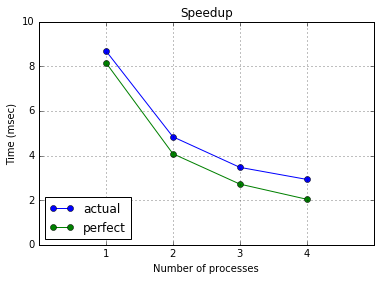

```python
plt.plot(np, e_times, 'o-', label='actual')
plt.plot(np, p_times, 'o-', label='perfect')
plt.legend(loc='lower left')
plt.axis([0,5,0,10])
plt.title('Speedup')
plt.xticks(range(1,5))
plt.xlabel('Number of processes')
plt.ylabel('Time (msec)')
plt.grid(True)
```

## Parallel Biome Simulation?

It should be possible to create a SPMD version of the biome simulation

- divide the world up into sub-grids
- allocate one sub-grid to each process

[figure not shown]

There are several thorny issues to resolve, however:

- the processes need to syncrhonize -- *e.g.* P2 can't begin a new time step until P1 and P3 have completed the same step
- animals need to be able to migrate from one zone to another

### Shared Data

The general problem: processes need to share data structures

- there need to be mechanisms that ensure only one process at a time updates the shared regions

### Embarassingly Parallel

In the example used to illustrate `Pool.map`:

- all computations in that example can run independently
- there is no need for one process to communicate with the others

These sorts of problems are "embarassingly" parallel -- it doesn't take much work to figure out how to run them